# 15492.necrography.response

## stephan schwarz, EXC2020-FUB

## traces and gaps

in the world-of-things-being stolen objects form a knowledge graph which is missing important elements. missing, because simply the link tree from creation of to the objects today status is incomplete. important, because these missing links such as knowledge graphs work fail to display the biography of the object resp. they display a distorted picture - from which you would not be able to tell the history and context embedding of the thing in question. take a rodin sculpture: you can line up it’s history from the marble being broken in Carrara via rilkes contemplations to the louvre student finishing her masters thesis about :gender aspects of greek mythology:. / and take a benin bronze sculpture, resting in the berlin ethnologische museum: the circle-of-life of that has been at some point interrupted or been forced to bridge a gap between it’s benin royal palace (inhabitance: as we dont know :if: the **head of idia** once :lived: there or what (she) was doing besides being rested in that kings house) and the some-admirals revenue for it arriving in london and the final again display in a security glass vitrine. there’s whitespaces in this biography and errands disrupting the destiny of the **event of the artistic item** as hicks puts it. it would take much effort to restore that destiny and bringing to place each belonging at it’s assigned slot in time is not possible. so rewriting that gaps in the sense of the outlined **necrography** isnt possibly done by western institutions in noble restitutional acts. even if these acts take on humble gestures of apology, the biographical traces of the creative performance are lost and cannot be invented today. ## a ulysses network

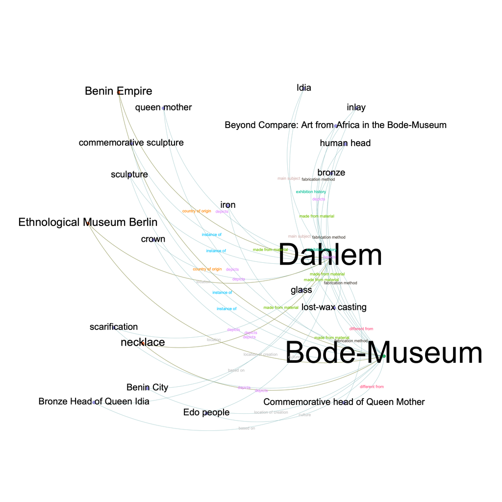

Q: taxonomy of wikidata item Q106983702

we see in the graph that there’s no nodes containing clues that would make us suspicious about the item in question. diving deeper into linked datapoints to the british museum e.g. we find that something mustebeen **looted** and sold and gaining high revenue for obviously not the personal to which the item belonged originally. sure one can categorise this under surplus value of art pieces which often make their way like this in (society.) the point of difference here lies in the way…, the curriculum… in which artistic works travel. above mentioned rodin sculptures sure did not experience an interruption of their biography from genesis to todays display and everything seems clear, every participant may have been compensated and left its mark in the history of the object. the life marks of the creators and possesors of idia, queen of edo, have been erased in the course of the wandering statue and will not show again on the bronze surface. ## for good it seems that the hopefully penible cataloguing of each looted item and the careful conservation of the original status can halfway help getting over the missing links in the first place. and as for every western renaissance artwork the historiographs wil find ways to maybe even restore the context of the items. and if still not items, the context of today edo nation probably has moved away from any context in which the items may have been placed in times of question, so re-contextualising their state would be, viewed from both sides of the hegemony, a restaurative act, an attempt to conserve what is today the past of colonisers and colonised and less desirable. only the moral remains: dont tear art out of its context.